# CapstoneProject

Nguyen Nguyen

1/28/2022

## STEP 1: ASK

#### 1.0 Background

You are a junior data analyst working on the marketing analyst team at Bellabeat, a high-tech manufacturer of health-focused products for women. Bellabeat is a successful small company, but they have the potential to become a larger player in the global smart device market. Urška Sršen, cofounder and Chief Creative Officer of Bellabeat, believes that analyzing smart device fitness data could help unlock new growth opportunities for the company. You have been asked to focus on one of Bellabeat’s products and analyze smart device data (ie. FitBit fitness tracker usage data) to gain insight into how consumers are using their smart devices. The insights you discover will then help guide marketing strategy for the company. You will present your analysis to the Bellabeat executive team along with your high-level recommendations for Bellabeat’s marketing strategy.

#### 1.2 Business Task:

Analyze FitBit Fitness Tracker Data to gain insights into how consumers are using the FitBit app and discover trends and insights for Bellabeat marketing strategy.

#### 1.3 Business Objectives:

1. What are some trends in smart device usage?
2. How could these trends apply to Bellabeat customers?
3. How could these trends help influence Bellabeat marketing strategy?

### 1.4 Deliverables:

1. A clear summary of the business task
2. A description of all data sources used
3. Documentation of any cleaning or manipulation of data
4. A summary of analysis
5. Supporting visualizations and key findings
6. Your top high-level content recommendations based on your analysis

#### 1.5 Key Stakeholders:

Urška Sršen: Bellabeat’s cofounder and Chief Creative Officer

Sando Mur: Mathematician and Bellabeat’s cofounder; key member of the Bellabeat executive team

Bellabeat marketing analytics team: A team of data analysts responsible for collecting, analyzing, and reporting data that helps guide Bellabeat’s marketing strategy. You joined this team six months ago and have been busy learning about Bellabeat’’s mission and business goals — as well as how you, as a junior data analyst, can help Bellabeat achieve them.

## STEP 2: PREPARE

#### 2.3 Is Data ROCCC?

A good data source is ROCCC which stands for Reliable, Original, Comprehensive, Current, and Cited.

Original - LOW - Provided by a third party (Amazon Mechanical Turk)

Comprehensive - MED - Most of Bellabeat’s products have criteria that match those of.

Current - LOW - Data is 6 years old and no longer relevant.

Cited - LOW - Data was obtained from a third party, hence the source is unclear.

Overall, the dataset is of poor quality, and it is not recommended that business recommendations be based on it.

#### 2.4 Data Selection:

The “dailyActivity_merged.csv” file is chosen and copied for analysis.

## STEP 3: PROCESS

We are using R for data preparation and processing.

#### 3.1 Preparing the Environment:

Import the library that we will use to clean, process, and visulaize the data

```r
library(tidyverse)
library(readr)
library(dplyr)
library(tibble)
library(psych)
library(ggplot2)
library(tidyverse)
library(RColorBrewer)
```

#### 3.2 Importing data set

Reading in the file to be used for analysis.

```r
# importing the csv file that I will be using
dailyActivity_merged <- read_csv("/Users/nguyennguyen/Downloads/Fitabase Data 4.12.16-5.12.16/dailyActivity_merged.csv")
```

#### 3.3 Data cleaning and manipulation

Previewing the data using the glimpse function to familiralize with the data

```r
glimpse(dailyActivity_merged)
```

```
## Rows: 940
## Columns: 15
## $ Id                       <dbl> 1503960366, 1503960366, 1503960366, 150396036…
## $ ActivityDate             <chr> "4/12/2016", "4/13/2016", "4/14/2016", "4/15/…
## $ TotalSteps               <dbl> 13162, 10735, 10460, 9762, 12669, 9705, 13019…
## $ TotalDistance            <dbl> 8.50, 6.97, 6.74, 6.28, 8.16, 6.48, 8.59, 9.8…
## $ TrackerDistance          <dbl> 8.50, 6.97, 6.74, 6.28, 8.16, 6.48, 8.59, 9.8…
## $ LoggedActivitiesDistance <dbl> 0, 0, 0, 0, 0, 0, 0, 0, 0, 0, 0, 0, 0, 0, 0, …
## $ VeryActiveDistance       <dbl> 1.88, 1.57, 2.44, 2.14, 2.71, 3.19, 3.25, 3.5…
## $ ModeratelyActiveDistance <dbl> 0.55, 0.69, 0.40, 1.26, 0.41, 0.78, 0.64, 1.3…
## $ LightActiveDistance      <dbl> 6.06, 4.71, 3.91, 2.83, 5.04, 2.51, 4.71, 5.0…
## $ SedentaryActiveDistance  <dbl> 0, 0, 0, 0, 0, 0, 0, 0, 0, 0, 0, 0, 0, 0, 0, …
## $ VeryActiveMinutes        <dbl> 25, 21, 30, 29, 36, 38, 42, 50, 28, 19, 66, 4…
## $ FairlyActiveMinutes      <dbl> 13, 19, 11, 34, 10, 20, 16, 31, 12, 8, 27, 21…
## $ LightlyActiveMinutes     <dbl> 328, 217, 181, 209, 221, 164, 233, 264, 205, …
## $ SedentaryMinutes         <dbl> 728, 776, 1218, 726, 773, 539, 1149, 775, 818…
## $ Calories                 <dbl> 1985, 1797, 1776, 1745, 1863, 1728, 1921, 203…
```

Find out if there is any missing data in the dailyActivity_merged

```r
# obtain the number of missing data points per column
missing_values_count =  sum(is.na(dailyActivity_merged))
missing_values_count
```

```
## [1] 0
```

Finding out the basic structure of daily_activity:

1. number of rows and columns
2. name of columns
3. type of values

```r
# show structure of data
str(dailyActivity_merged)
```

```
## spec_tbl_df [940 × 15] (S3: spec_tbl_df/tbl_df/tbl/data.frame)
##  $ Id                      : num [1:940] 1.5e+09 1.5e+09 1.5e+09 1.5e+09 1.5e+09 ...
##  $ ActivityDate            : chr [1:940] "4/12/2016" "4/13/2016" "4/14/2016" "4/15/2016" ...
##  $ TotalSteps              : num [1:940] 13162 10735 10460 9762 12669 ...
##  $ TotalDistance           : num [1:940] 8.5 6.97 6.74 6.28 8.16 ...
##  $ TrackerDistance         : num [1:940] 8.5 6.97 6.74 6.28 8.16 ...
##  $ LoggedActivitiesDistance: num [1:940] 0 0 0 0 0 0 0 0 0 0 ...
##  $ VeryActiveDistance      : num [1:940] 1.88 1.57 2.44 2.14 2.71 ...
##  $ ModeratelyActiveDistance: num [1:940] 0.55 0.69 0.4 1.26 0.41 ...
##  $ LightActiveDistance     : num [1:940] 6.06 4.71 3.91 2.83 5.04 ...
##  $ SedentaryActiveDistance : num [1:940] 0 0 0 0 0 0 0 0 0 0 ...
##  $ VeryActiveMinutes       : num [1:940] 25 21 30 29 36 38 42 50 28 19 ...
##  $ FairlyActiveMinutes     : num [1:940] 13 19 11 34 10 20 16 31 12 8 ...
##  $ LightlyActiveMinutes    : num [1:940] 328 217 181 209 221 164 233 264 205 211 ...
##  $ SedentaryMinutes        : num [1:940] 728 776 1218 726 773 ...
##  $ Calories                : num [1:940] 1985 1797 1776 1745 1863 ...
##  - attr(*, "spec")=
##   .. cols(
##   ..   Id = col_double(),
##   ..   ActivityDate = col_character(),
##   ..   TotalSteps = col_double(),
##   ..   TotalDistance = col_double(),
##   ..   TrackerDistance = col_double(),
##   ..   LoggedActivitiesDistance = col_double(),
##   ..   VeryActiveDistance = col_double(),
##   ..   ModeratelyActiveDistance = col_double(),
##   ..   LightActiveDistance = col_double(),
##   ..   SedentaryActiveDistance = col_double(),
##   ..   VeryActiveMinutes = col_double(),
##   ..   FairlyActiveMinutes = col_double(),
##   ..   LightlyActiveMinutes = col_double(),
##   ..   SedentaryMinutes = col_double(),
##   ..   Calories = col_double()
##   .. )
##  - attr(*, "problems")=<externalptr>
```

Note that the data frame has 940 rows and 15 columns and all of the columns are num type except for the ActivityDate column, which is chr type.

Check for the unique ID values in the table

```r
# count distinct value of "Id"
unique_id <- n_distinct(dailyActivity_merged$Id)
print(paste("Number of unique ID: ", unique_id))
```

```
## [1] "Number of unique ID:  33"
```

Create a copy of the data frame andadding three columns: DayOfWeek, TotalExerciseMinutes, and TotalExerciseHours to manipulate and make further calculation for analysis.

```r
# create a copy of the table to manipulate
# adding three columns: DayOfWeek, TotalExerciseMinutes, and TotalExerciseHours
# fill the columns with NaN
copy_daily <- dailyActivity_merged %>%
  add_column(DayOfWeek = NaN, .after = "ActivityDate") %>%
  add_column(TotalExcerciseMinutes = NaN, .after = "SedentaryMinutes") %>%
  add_column(TotalExcerciseHours = NaN, .after = "TotalExcerciseMinutes")

# verify that the columns had been added successfully
str(copy_daily)
```

```
## spec_tbl_df [940 × 18] (S3: spec_tbl_df/tbl_df/tbl/data.frame)
##  $ Id                      : num [1:940] 1.5e+09 1.5e+09 1.5e+09 1.5e+09 1.5e+09 ...
##  $ ActivityDate            : chr [1:940] "4/12/2016" "4/13/2016" "4/14/2016" "4/15/2016" ...
##  $ DayOfWeek               : num [1:940] NaN NaN NaN NaN NaN NaN NaN NaN NaN NaN ...
##  $ TotalSteps              : num [1:940] 13162 10735 10460 9762 12669 ...
##  $ TotalDistance           : num [1:940] 8.5 6.97 6.74 6.28 8.16 ...
##  $ TrackerDistance         : num [1:940] 8.5 6.97 6.74 6.28 8.16 ...
##  $ LoggedActivitiesDistance: num [1:940] 0 0 0 0 0 0 0 0 0 0 ...
##  $ VeryActiveDistance      : num [1:940] 1.88 1.57 2.44 2.14 2.71 ...
##  $ ModeratelyActiveDistance: num [1:940] 0.55 0.69 0.4 1.26 0.41 ...
##  $ LightActiveDistance     : num [1:940] 6.06 4.71 3.91 2.83 5.04 ...
##  $ SedentaryActiveDistance : num [1:940] 0 0 0 0 0 0 0 0 0 0 ...
##  $ VeryActiveMinutes       : num [1:940] 25 21 30 29 36 38 42 50 28 19 ...
##  $ FairlyActiveMinutes     : num [1:940] 13 19 11 34 10 20 16 31 12 8 ...
##  $ LightlyActiveMinutes    : num [1:940] 328 217 181 209 221 164 233 264 205 211 ...
##  $ SedentaryMinutes        : num [1:940] 728 776 1218 726 773 ...
##  $ TotalExcerciseMinutes   : num [1:940] NaN NaN NaN NaN NaN NaN NaN NaN NaN NaN ...
##  $ TotalExcerciseHours     : num [1:940] NaN NaN NaN NaN NaN NaN NaN NaN NaN NaN ...
##  $ Calories                : num [1:940] 1985 1797 1776 1745 1863 ...
##  - attr(*, "spec")=
##   .. cols(
##   ..   Id = col_double(),
##   ..   ActivityDate = col_character(),
##   ..   TotalSteps = col_double(),
##   ..   TotalDistance = col_double(),
##   ..   TrackerDistance = col_double(),
##   ..   LoggedActivitiesDistance = col_double(),
##   ..   VeryActiveDistance = col_double(),
##   ..   ModeratelyActiveDistance = col_double(),
##   ..   LightActiveDistance = col_double(),
##   ..   SedentaryActiveDistance = col_double(),
##   ..   VeryActiveMinutes = col_double(),
##   ..   FairlyActiveMinutes = col_double(),
##   ..   LightlyActiveMinutes = col_double(),
##   ..   SedentaryMinutes = col_double(),
##   ..   Calories = col_double()
##   .. )
##  - attr(*, "problems")=<externalptr>
```

The following data manipulation is performed:

1. For further analysis, populate column DayOfTheWeek by separating the date into days of the week.
2. Populate column TotalExcerciseMinutes by summing up VeryActiveMinutes, FairlyActiveMinutes, LightlyActiveMinutes and SedentaryMinutes.
3. populate column TotalHours by dividing the TotalExcerciseMinutes by 60.

```r
# Populate the values for the DayOfWeek column
copy_daily$DayOfWeek = weekdays(as.Date(dailyActivity_merged$ActivityDate, "%m/%d/%Y"))


# Populate the TotalExcerciseMinutes column by adding up all of the minutes of the corresponding day
copy_daily$TotalExcerciseMinutes = copy_daily$VeryActiveMinutes + copy_daily$FairlyActiveMinutes + copy_daily$LightlyActiveMinutes + copy_daily$SedentaryMinutes


# Populate the TotalExcerciseHours column by dividing the TotalExcerciseMinutes by 60
copy_daily$TotalExcerciseHours = round(copy_daily$TotalExcerciseMinutes/60, digits=0)

# verify that the columns have been populated successfully
glimpse(copy_daily)
```

```
## Rows: 940
## Columns: 18
## $ Id                       <dbl> 1503960366, 1503960366, 1503960366, 150396036…
## $ ActivityDate             <chr> "4/12/2016", "4/13/2016", "4/14/2016", "4/15/…
## $ DayOfWeek                <chr> "Tuesday", "Wednesday", "Thursday", "Friday",…
## $ TotalSteps               <dbl> 13162, 10735, 10460, 9762, 12669, 9705, 13019…
## $ TotalDistance            <dbl> 8.50, 6.97, 6.74, 6.28, 8.16, 6.48, 8.59, 9.8…
## $ TrackerDistance          <dbl> 8.50, 6.97, 6.74, 6.28, 8.16, 6.48, 8.59, 9.8…
## $ LoggedActivitiesDistance <dbl> 0, 0, 0, 0, 0, 0, 0, 0, 0, 0, 0, 0, 0, 0, 0, …
## $ VeryActiveDistance       <dbl> 1.88, 1.57, 2.44, 2.14, 2.71, 3.19, 3.25, 3.5…
## $ ModeratelyActiveDistance <dbl> 0.55, 0.69, 0.40, 1.26, 0.41, 0.78, 0.64, 1.3…
## $ LightActiveDistance      <dbl> 6.06, 4.71, 3.91, 2.83, 5.04, 2.51, 4.71, 5.0…
## $ SedentaryActiveDistance  <dbl> 0, 0, 0, 0, 0, 0, 0, 0, 0, 0, 0, 0, 0, 0, 0, …
## $ VeryActiveMinutes        <dbl> 25, 21, 30, 29, 36, 38, 42, 50, 28, 19, 66, 4…
## $ FairlyActiveMinutes      <dbl> 13, 19, 11, 34, 10, 20, 16, 31, 12, 8, 27, 21…
## $ LightlyActiveMinutes     <dbl> 328, 217, 181, 209, 221, 164, 233, 264, 205, …
## $ SedentaryMinutes         <dbl> 728, 776, 1218, 726, 773, 539, 1149, 775, 818…
## $ TotalExcerciseMinutes    <dbl> 1094, 1033, 1440, 998, 1040, 761, 1440, 1120,…
## $ TotalExcerciseHours      <dbl> 18, 17, 24, 17, 17, 13, 24, 19, 18, 18, 24, 1…
## $ Calories                 <dbl> 1985, 1797, 1776, 1745, 1863, 1728, 1921, 203…
```

The data cleaning and manipulation process has been completed. As a result, the data is now ready for analysis.

## STEP 4: ANALYZE

#### 4.1 Perform calculations

Pulling the statistics of copy_daily for analysis:

1. count - number of rows
2. mean (average)
3. std (standard deviation)
4. min
5. max

```r
# getting the general statistics of the table
format(describeBy(copy_daily), scientific=FALSE)
```

```
##                          vars   n                 mean                   sd
## Id                          1 940 4855407369.332978249 2424805475.657959938
## ActivityDate*               2 940         15.410638298          8.913708533
## DayOfWeek*                  3 940          4.169148936          2.015938968
## TotalSteps                  4 940       7637.910638298       5087.150741753
## TotalDistance               5 940          5.489702122          3.924605909
## TrackerDistance             6 940          5.475351058          3.907275943
## LoggedActivitiesDistance    7 940          0.108170940          0.619896518
## VeryActiveDistance          8 940          1.502680851          2.658941165
## ModeratelyActiveDistance    9 940          0.567542551          0.883580319
## LightActiveDistance        10 940          3.340819149          2.040655388
## SedentaryActiveDistance    11 940          0.001606383          0.007346176
## VeryActiveMinutes          12 940         21.164893617         32.844803057
## FairlyActiveMinutes        13 940         13.564893617         19.987403954
## LightlyActiveMinutes       14 940        192.812765957        109.174699751
## SedentaryMinutes           15 940        991.210638298        301.267436790
## TotalExcerciseMinutes      16 940       1218.753191489        265.931767055
## TotalExcerciseHours        17 940         20.313829787          4.437282772
## Calories                   18 940       2303.609574468        718.166862134
##                                  median            trimmed               mad
## Id                       4445114986.000 4777480921.4188833 3586057951.152600
## ActivityDate*                    15.000         15.3018617         11.860800
## DayOfWeek*                        4.000          4.2114362          2.965200
## TotalSteps                     7405.500       7388.2579787       5109.780900
## TotalDistance                     5.245          5.2027394          3.795456
## TrackerDistance                   5.245          5.1948404          3.788043
## LoggedActivitiesDistance          0.000          0.0000000          0.000000
## VeryActiveDistance                0.210          0.8845878          0.311346
## ModeratelyActiveDistance          0.240          0.3758910          0.355824
## LightActiveDistance               3.365          3.3155186          2.105292
## SedentaryActiveDistance           0.000          0.0000000          0.000000
## VeryActiveMinutes                 4.000         14.0039894          5.930400
## FairlyActiveMinutes               6.000          9.3603723          8.895600
## LightlyActiveMinutes            199.000        193.5492021        102.299400
## SedentaryMinutes               1057.500        998.6289894        386.958600
## TotalExcerciseMinutes          1440.000       1251.0398936          0.000000
## TotalExcerciseHours              24.000         20.8444149          0.000000
## Calories                       2134.000       2261.1023936        692.374200
##                                 min               max             range
## Id                       1503960366 8877689391.000000 7373729025.000000
```

[output cut: 21 more lines]

```
## TotalSteps                0.65081271  1.1476866      165.9245620350
## TotalDistance             1.12268169  3.0771574        0.1280065305
## TrackerDistance           1.13093128  3.1673533        0.1274412893
## LoggedActivitiesDistance  6.27735641 40.9765157        0.0202187951
## VeryActiveDistance        2.98661453 11.8097523        0.0867250983
## ModeratelyActiveDistance  2.76235564 10.0376887        0.0288192123
## LightActiveDistance       0.18166624 -0.1917035        0.0665588399
## SedentaryActiveDistance   8.56250402 98.3785375        0.0002396059
## VeryActiveMinutes         2.16920300  5.7224172        1.0712793544
## FairlyActiveMinutes       2.47158430  7.9236091        0.6519172353
## LightlyActiveMinutes     -0.03780838 -0.3701857        3.5608860758
## SedentaryMinutes         -0.29355887 -0.6737466        9.8262603258
## TotalExcerciseMinutes    -1.01550318  1.1107889        8.6737378583
## TotalExcerciseHours      -1.01908037  1.1328578        0.1447282060
## Calories                  0.42110319  0.6076430       23.4240202653
```

**Interpreting statistical findings:**

Users logged 7,638 steps on average, which is insufficient. According to the CDC, an adult should aim for at least 10,000 steps per day to benefit from general health, weight loss, and fitness improvement.

It is worth noting that the average number of calories burned is 2,303. Could not go into detail because calories burned are affected by a variety of factors like age, mass, everyday chores, exercise, hormones, and everyday calorie consumption.

## STEP 5: SHARE

We are producing visuals and presenting our conclusions based on our analysis in this step.

#### 5.1 Data Visualisation and Findings

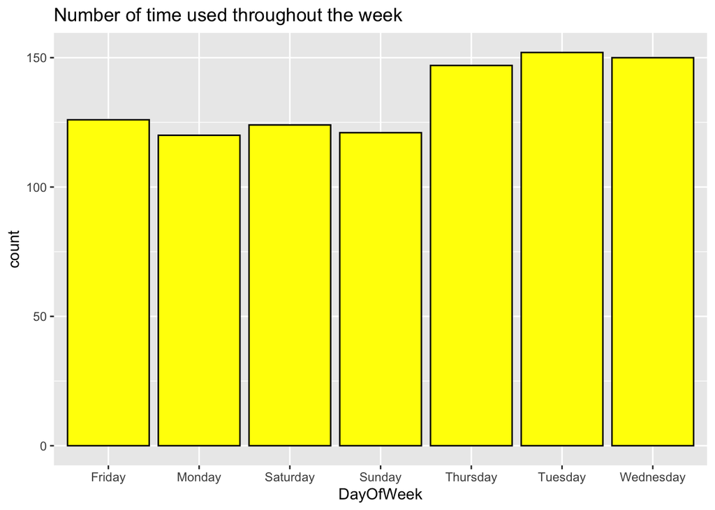

```r
# displaying the bar graph to see how often the users use the app throughout the week
ggplot(data=copy_daily, mapping= aes(x=DayOfWeek)) +
  geom_bar(color="black", fill="yellow" ) +
  labs(title = "Number of time used throughout the week")
```

**Frequency of usage across the week**

We’re looking at the regularity of FitBit app usage in terms of days of the week in this graph.

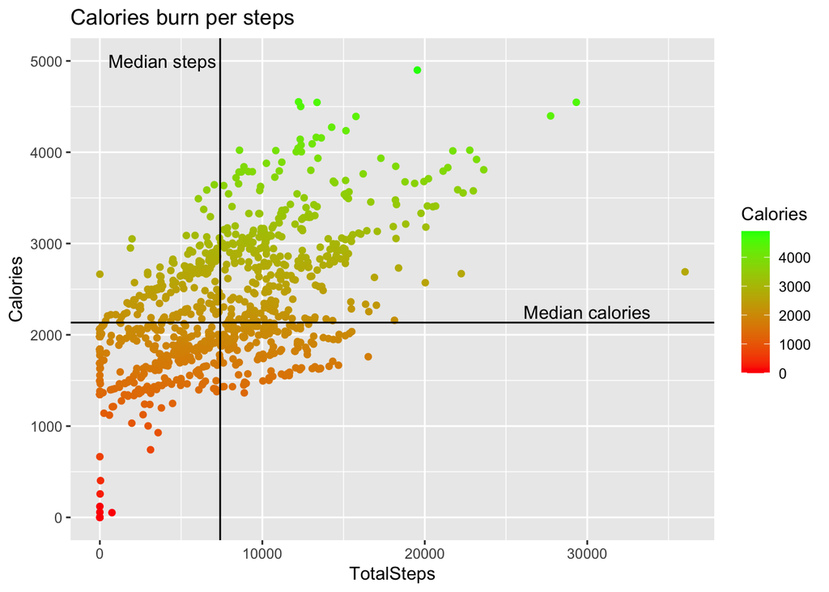

```r
# extract the median calories and steps from above table
med_calories <-  2134
med_steps <- 7405

# scatter plot to graph Calories vs TotalSteps
# also plot the median calories and median steps
ggplot(data=copy_daily,mapping=aes(x=TotalSteps, y=Calories,color=Calories)) + geom_point() + scale_colour_gradient(low="red", high="green") +
  geom_hline(yintercept = med_calories)+
  geom_vline(xintercept = med_steps) +
  labs(title = "Calories burn per steps")+
  annotate("text",x=3850, y=5000,label="Median steps")+
  annotate("text",x=30000, y=2250,label="Median calories")
```

**Every step you take burns calories.**

We discovered from the scatter plot:

1. It is a positive relationship.
2. We discovered that the intensity of calories burned increases when users are between 0 and 14,000 steps, with the rate of calories burned decreasing after 14,000 steps.
3. There were a few outliers:
- No steps taken, and no to little calories were burned.
- One observation of more than 35,000 steps with less than 3,000 calories burnt.
- Outliers could happened due to the result of natural variance in data, changes in user activity, or errors in data collecting (ie. miscalculations, data contamination or human error).

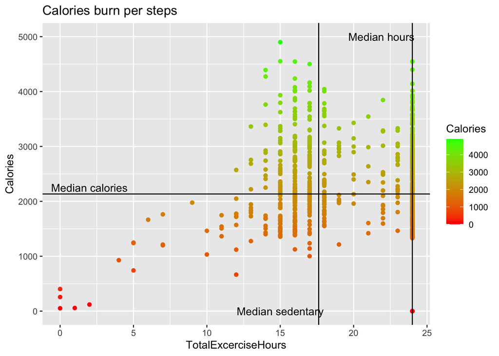

```r
# extract the median hours and sedentary hours from above table
med_hours <- 24
med_sedentary <- 1057/60

# scatter plot to graph Calories vs TotalExcerciseHours
# also plot the median calories, median total hours, and median sedentary hour
ggplot(data=copy_daily,mapping=aes(x=TotalExcerciseHours, y=Calories,color=Calories)) +
  geom_point() + scale_colour_gradient(low="red", high="green") +
  geom_hline(yintercept = med_calories)+
  geom_vline(xintercept = med_hours) +
  geom_vline(xintercept = med_sedentary) +
  labs(title = "Calories burn per steps") +
  annotate("text",x=2, y=2250,label="Median calories")+
  annotate("text",x=15, y=0,label="Median sedentary")+
  annotate("text",x=22, y=5000,label="Median hours ")
```

**Calories burned for each tracked hour**

The scatter plot reveals:

We can detect a few outliers once more:

- Outliers with the same zero value
- A strange red dot at 24 hours with no calories burned, which could be due to the same causes as stated above.

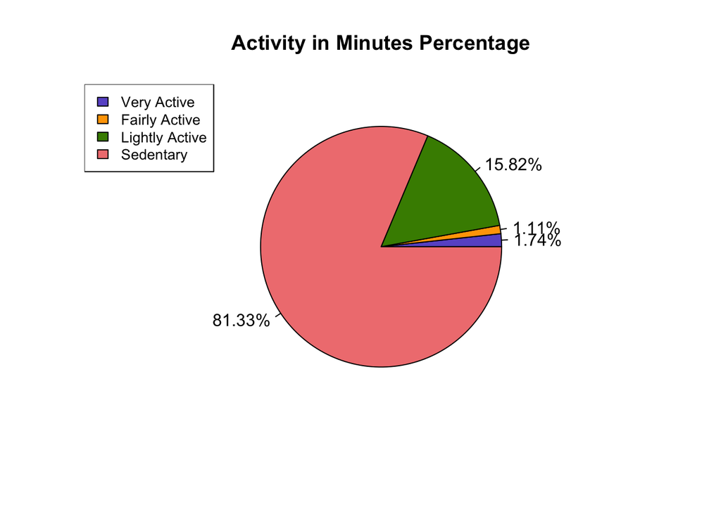

```r
# calculating total of individual minutes column
very_active_mins = sum(copy_daily$VeryActiveMinutes)
fairly_active_mins = sum(copy_daily$FairlyActiveMinutes)
lightly_active_mins = sum(copy_daily$LightlyActiveMinutes)
sedentary_mins = sum(copy_daily$SedentaryMinutes)

# pie chart to display the minutes columns
value=c(very_active_mins,fairly_active_mins,lightly_active_mins ,sedentary_mins)
pie_labels <- paste0(round(100 * value/sum(value), 2), "%")
pie(value, labels = pie_labels,col=c("slateblue", "orange", "chartreuse4", "lightcoral"),main = "Activity in Minutes Percentage")

# legend of the pie chart
legend("topleft", inset = -.0001, legend = c("Very Active","Fairly Active","Lightly Active" ,"Sedentary"), fill =  c("slateblue", "orange", "chartreuse4", "lightcoral"),cex = 0.85)
```

**Minutes of Activity as a Percentage**

As evidenced by the pie chart:

1. Sedentary minutes account for the largest chunk, accounting for 81.3 percent.
2. This means that users are logging everyday activities such as daily commutes, idle movements (going from one location to another), or doing errands using the FitBit app.
3. According to the modest percentage of fairly active activity (1.1 percent) and very active activity (1.7 percent), the app is rarely used to track fitness. This is quite discouraging because the FitBit app was designed to promote fitness.

## STEP 6: ACT

In the final stage, we will present our findings and make suggestions based on our study.

In this section, we review our business questions and discuss our high-level business recommendations.

**2. What implications do these patterns have for Bellabeat customers?**

- Both companies create products aimed at giving women with information on their health, behaviors, and fitness, as well as helping them to understand their present styles and make good choices. These prevalent health and fitness trends can very well be applied to Bellabeat clients.

**3. How can these tendencies affect Bellabeat’s marketing strategy?**

- The Bellabeat marketing team can encourage customers by teaching and preparing them with knowledge about fitness benefits, recommending different forms of exercise, and providing calories consumption and burn summary data on the Bellabeat app.
- On weekends, the Bellabeat app can send notifications to motivate users to workout.